# Metformin & Analgesics

#### 진통약제 3분위로 구하기

- 1단계 진통제 중에서도 1)acetaminophen 2)ibuprofen 3)dexibuprofen 으로 나눠서 정의함
- 구할 때는 빈도수가 부족하므로, 기준 1(총처방일수로 계산한 15일 이상인 달 6회 이상)만 적용함

```r
### acetaminophen
medicine_a <- medicine_p %>% filter(grepl('acetaminophen', name))

t60_a <- t60 %>%
  dplyr::mutate(ATC_CAT = substr(GNL_NM_CD, 1, 4)) %>%
  dplyr::filter(ATC_CAT %in% medicine_a$ATC_CAT) %>%
  dplyr::inner_join(medicine_a)
ace <- t60_a %>%
  inner_join(t20 %>% dplyr::select(PERSON_ID, KEY_SEQ, RECU_FR_DT))  %>%
  dplyr::left_join(df %>% dplyr::select(PERSON_ID, INDEX_DATE, INDEX_CANCER, duration))

ace <- ace %>% filter(ymd(RECU_FR_DT) - ymd(INDEX_DATE) >= 0)
ace <- ace %>% filter(ymd(RECU_FR_DT) - ymd(INDEX_DATE) <= 365*2)

ace <- ace %>% dplyr::select(-c(Code))
ace_n <- ace %>% group_by(PERSON_ID, RECU_FR_DT, name) %>% summarise(kind_num = n(), day_sum = sum(MDCN_EXEC_FREQ))
ace_n <- ace_n %>% mutate(r_day = as.integer(day_sum / kind_num),
                          yearmon = substr(RECU_FR_DT,1,6))

ace_p_sum <- ace_n %>% group_by(PERSON_ID, yearmon) %>% summarise(t_1 = sum(day_sum), t_2 = sum(r_day))
ace_p_sum_1 <- ace_p_sum %>% mutate(month_t = ifelse(t_1>=15,1,0)) # 한달 단위 처방 일수
ace_p_sum_2 <- ace_p_sum %>% mutate(month_t = ifelse(t_2>=15,1,0)) # 한달 단위 하루 평균 처방량

# 진통약제를 15일 이상 받은 달이 6번 이상이면 환자면 regular?
ace_1 <- ace_p_sum_1 %>% group_by(PERSON_ID) %>% summarise(month = sum(month_t)) # 한달 단위 처방 일수
ace_1 <- ace_1 %>% mutate(a_rg = ifelse(month >= 6, 2, 1))
ace_2 <- ace_p_sum_2 %>% group_by(PERSON_ID) %>% summarise(month = sum(month_t)) # 한달 단위 하루 평균 처방량
ace_2 <- ace_2 %>% mutate(a_rg_2 = ifelse(month >= 6, 2, 1))

df <- df %>% left_join(ace_1 %>% select(PERSON_ID, a_rg))
df <- df %>% left_join(ace_2 %>% select(PERSON_ID, a_rg_2))
df <- df %>% mutate(ace1=ifelse(is.na(a_rg),0,a_rg),
                    ace2=ifelse(is.na(a_rg_2),0,a_rg_2))

### ibuprofen
medicine_i <- medicine_p %>% filter(grepl('ibuprofen', name))
medicine_i <- medicine_i %>% filter(!grepl('dexi', name))

t60_i <- t60 %>%
  dplyr::mutate(ATC_CAT = substr(GNL_NM_CD, 1, 4)) %>%
  dplyr::filter(ATC_CAT %in% medicine_i$ATC_CAT) %>%
  dplyr::inner_join(medicine_i)
ibu <- t60_i %>%
  inner_join(t20 %>% dplyr::select(PERSON_ID, KEY_SEQ, RECU_FR_DT))  %>%
  dplyr::left_join(df %>% dplyr::select(PERSON_ID, INDEX_DATE, INDEX_CANCER, duration))

# 1년 단위를 뽑아서, 처방 빈도가 20번 이상이면 regular, 아니면 non-regular, 기록이 없으면 none
ibu <- ibu %>% filter(ymd(RECU_FR_DT) - ymd(INDEX_DATE) >= 0)
ibu <- ibu %>% filter(ymd(RECU_FR_DT) - ymd(INDEX_DATE) <= 365*2)

ibu <- ibu %>% dplyr::select(-c(Code)) #%>% unique() %>% arrange(PERSON_ID, RECU_FR_DT)
ibu_n <- ibu %>% group_by(PERSON_ID, RECU_FR_DT, name) %>% summarise(kind_num = n(), day_sum = sum(MDCN_EXEC_FREQ))
ibu_n <- ibu_n %>% mutate(r_day = as.integer(day_sum / kind_num),
                          yearmon = substr(RECU_FR_DT,1,6))

ibu_p_sum <- ibu_n %>% group_by(PERSON_ID, yearmon) %>% summarise(t_1 = sum(day_sum), t_2 = sum(r_day))
ibu_p_sum_1 <- ibu_p_sum %>% mutate(month_t = ifelse(t_1>=15,1,0)) # 한달 단위 처방 일수
ibu_p_sum_2 <- ibu_p_sum %>% mutate(month_t = ifelse(t_2>=15,1,0)) # 한달 단위 처방 일수

# 진통약제를 15일 이상 받은 달이 6번 이상이면 환자면 regular?
ibu_1 <- ibu_p_sum_1 %>% group_by(PERSON_ID) %>% summarise(month = sum(month_t)) # 한달 단위 처방 일수
ibu_1 <- ibu_1 %>% mutate(i_rg = ifelse(month >= 6, 2, 1))
ibu_2 <- ibu_p_sum_2 %>% group_by(PERSON_ID) %>% summarise(month = sum(month_t)) # 한달 단위 하루 평균 처방량
ibu_2 <- ibu_2 %>% mutate(i_rg_2 = ifelse(month >= 6, 2, 1))

df <- df %>% left_join(ibu_1 %>% select(PERSON_ID, i_rg))
df <- df %>% left_join(ibu_2 %>% select(PERSON_ID, i_rg_2))
df <- df %>% mutate(ibu1=ifelse(is.na(i_rg),0,i_rg),
                    ibu2=ifelse(is.na(i_rg_2),0,i_rg_2))

### dexibuprofen
medicine_x <- medicine_p %>% filter(grepl('dexibuprofen', name))

t60_x <- t60 %>%
  dplyr::mutate(ATC_CAT = substr(GNL_NM_CD, 1, 4)) %>%
  dplyr::filter(ATC_CAT %in% medicine_x$ATC_CAT) %>%
  dplyr::inner_join(medicine_x)
dex <- t60_x %>%
  inner_join(t20 %>% dplyr::select(PERSON_ID, KEY_SEQ, RECU_FR_DT))  %>%
  dplyr::left_join(df %>% dplyr::select(PERSON_ID, INDEX_DATE, INDEX_CANCER, duration))

dex <- dex %>% filter(ymd(RECU_FR_DT) - ymd(INDEX_DATE) >= 0)
dex <- dex %>% filter(ymd(RECU_FR_DT) - ymd(INDEX_DATE) <= 365*2)

dex <- dex %>% dplyr::select(-c(Code))
dex_n <- dex %>% group_by(PERSON_ID, RECU_FR_DT, name) %>% summarise(kind_num = n(), day_sum = sum(MDCN_EXEC_FREQ))
dex_n <- dex_n %>% mutate(r_day = as.integer(day_sum / kind_num),
                          yearmon = substr(RECU_FR_DT,1,6))

dex_p_sum <- dex_n %>% group_by(PERSON_ID, yearmon) %>% summarise(t_1 = sum(day_sum), t_2 = sum(r_day))
dex_p_sum_1 <- dex_p_sum %>% mutate(month_t = ifelse(t_1>=15,1,0)) # 한달 단위 처방 일수
dex_p_sum_2 <- dex_p_sum %>% mutate(month_t = ifelse(t_2>=15,1,0)) # 한달 단위 처방 일수

# 진통약제를 15일 이상 받은 달이 6번 이상이면 환자면 regular?
dex_1 <- dex_p_sum_1 %>% group_by(PERSON_ID) %>% summarise(month = sum(month_t)) # 한달 단위 처방 일수
dex_1 <- dex_1 %>% mutate(d_rg = ifelse(month >= 6, 2, 1))
dex_2 <- dex_p_sum_2 %>% group_by(PERSON_ID) %>% summarise(month = sum(month_t)) # 한달 단위 하루 평균 처방량
dex_2 <- dex_2 %>% mutate(d_rg_2 = ifelse(month >= 6, 2, 1))

df <- df %>% left_join(dex_1 %>% select(PERSON_ID, d_rg))
df <- df %>% left_join(dex_2 %>% select(PERSON_ID, d_rg_2))
df <- df %>% mutate(dex1=ifelse(is.na(d_rg),0,d_rg),
                    dex2=ifelse(is.na(d_rg_2),0,d_rg_2))
```

#### 분류된 3가지 1단계 진통제 (acetaminophen, ibuprofen, dexibuprofen) 빈도표 (기준 1)

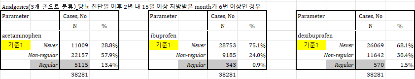

### Step 4. 분석 진행

- 주요 분석 내용은 Cox Regression

-> 암발생 여부를 종속변수로 두고, 코호트 추적기간을 고려한 Cox regression 을 통해 당뇨 환자들 내 암발생 여부와 다른 독립변수들이 유의한 연관을 보이는지 파악하기 위함

- 먼저 분석을 위해 필요한 변수 재정의 및 타입 정리

```r
df <- df %>% mutate(bmi = ifelse(BMI <25, 0, 1))
df$bmi <- factor(df$bmi, levels = c(0,1))
df$CD <- factor(df$CD, levels = c(0,1))
df <- df %>% mutate(age_t1 = ifelse(AGE_GROUP <= 8, "under40",
                                    ifelse(AGE_GROUP <=10, "40",
                                           ifelse(AGE_GROUP <= 12, "50",
                                                  ifelse(AGE_GROUP <= 14, "60", "up70")))))
df$age_t1 <- factor(df$age_t1, levels = c("under40", "40", "50", "60", "up70"))
df <- df %>% mutate(age = ifelse(AGE_GROUP <= 13, 0, 1)) # 0: 65세 미만, 1: 65세 이상
df$age <- factor(df$age, levels = c(0,1))
df <- df %>% mutate(gender = ifelse(SEX == 1, 0, 1)) # 0: 남자, 1: 여자
df$gender <- factor(df$gender, levels = c(0,1))

df <- df %>% mutate(death = ifelse(is.na(DTH_DATE) == F, 1, 0))
df$death <- factor(df$death, levels = c(1,0))
df <- df %>% mutate(smoke = ifelse(Smoking == 1, 0, 1),
                    alcohol = ifelse(Alcohol == 0, 0, 1),
                    exercise = ifelse(Exer == 0, 0, 1))
df$smoke <- factor(df$smoke, levels = c(0,1))
df$alcohol <- factor(df$alcohol, levels = c(0,1))
df$exercise <- factor(df$exercise, levels = c(0,1))
df$arth <- factor(df$arth, levels=c(0,1))
df$hyperlip <- factor(df$hyperlip, levels=c(0,1))
df$hyper <- factor(df$hyper, levels = c(0,1))
df$CCI_CAT <- factor(df$CCI_CAT, levels = c('0','1','2','3+'))
df <- df %>% mutate(tot_c = ifelse(TOT_CHOLE < 240, 0, 1))
df$tot_c <- factor(df$tot_c, levels = c(0,1))

df$metformin1 <- factor(df$metformin1, levels = c(0,1,2))
df$metformin2 <- factor(df$metformin2, levels = c(0,1,2))
df$metformin3 <- factor(df$metformin3, levels = c(0,1,2))
df$metformin4 <- factor(df$metformin4, levels = c(0,1,2))
df$metformin5 <- factor(df$metformin5, levels = c(0,1,2))

df$nsaid1 <- factor(df$nsaid1, levels = c(0,1,2))
df$nsaid2 <- factor(df$nsaid2, levels = c(0,1,2))
df$nsaid3 <- factor(df$nsaid3, levels = c(0,1,2))
df$ace1 <- factor(df$ace1, levels = c(0,1,2))
df$ace2 <- factor(df$ace2, levels = c(0,1,2))
df$ibu1 <- factor(df$ibu1, levels = c(0,1,2))
df$ibu2 <- factor(df$ibu2, levels = c(0,1,2))
df$dex1 <- factor(df$dex1, levels = c(0,1,2))
df$dex2 <- factor(df$dex2, levels = c(0,1,2))
```

#### 단계적 COX Regression

```r
# model_1
model1 <- coxph(Surv(duration, CD == 1) ~ metformin3 + age + gender, data=df)
summary(model1)

#model 2
model2 <- coxph(Surv(duration, CD == 1) ~ metformin3 + age + gender +
                  TOT_CHOLE + exercise + hyperlip + arth + hyper + CCI_CAT, data=df)
summary(model2)

#model 3
model3 <- coxph(Surv(duration, CD == 1) ~ metformin3 + age + gender +
                  TOT_CHOLE + exercise  + hyperlip + arth + hyper + CCI_CAT +
                  nsaid1, data=df)
summary(model3)
```

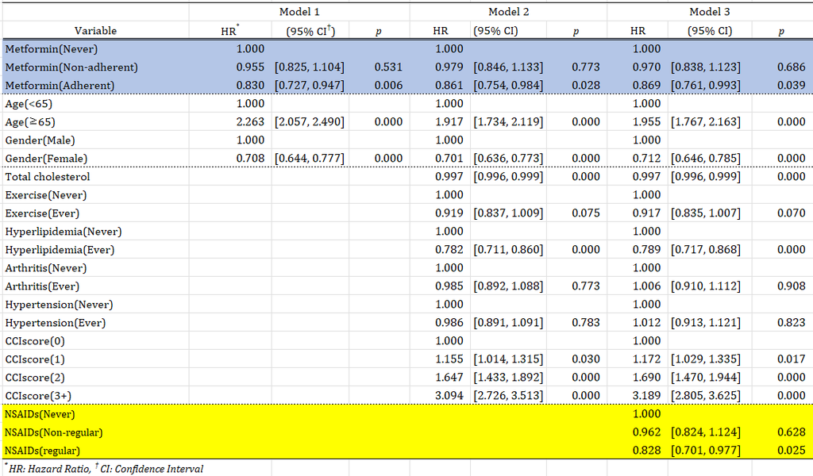

-> metformin과 1단계 진통제가 유의하게 나옴

#### metformin 순응군 별로 나눠서 COX Regression

```r
met0 <- df %>% filter(metformin3 == 0)
met1 <- df %>% filter(metformin3 == 1)
met2 <- df %>% filter(metformin3 == 2)

model1 <- coxph(Surv(duration, CD == 1) ~ age + gender +
                  TOT_CHOLE + exercise + hyperlip + arth + hyper + CCI_CAT +
                  nsaid1, data=met0)
summary(model1)

model2 <- coxph(Surv(duration, CD == 1) ~ age + gender +
                  TOT_CHOLE + exercise + hyperlip + arth + hyper + CCI_CAT +
                  nsaid1, data=met2)
summary(model2)

model3 <- coxph(Surv(duration, CD == 1) ~ age + gender +
                  TOT_CHOLE + exercise + hyperlip + arth + hyper + CCI_CAT +
                  nsaid1, data=met3)
summary(model3)
```

[figure not shown]